# ESTP training course

The required packages.

```r
library(RJDemetra)
library(JDLight)
```

Load two time-series from JDLight.

```r
a<-retail$HobbyToyAndGameStores
b<-retail$JewelryStores
```

# Preliminary analysis of the series

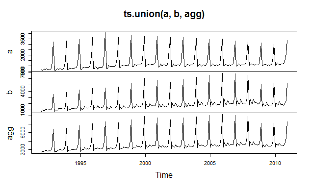

```r
agg<-a+b
plot(ts.union(a, b, agg))
```

We can notice the same pattern. E.g. the spikes in December. In addition we observe a spike in December 1996 in series a. However we do not notice the spike in the aggregate.

# Indirect Seasonal Adjusment

```r
a_x13<-x13_def(a,"RSA5")
a_sa<-a_x13$final$series[,"sa"]
b_x13<-x13_def(b,"RSA5")
b_sa<-b_x13$final$series[,"sa"]
```

We use X13 to seasonally adjust the two series.

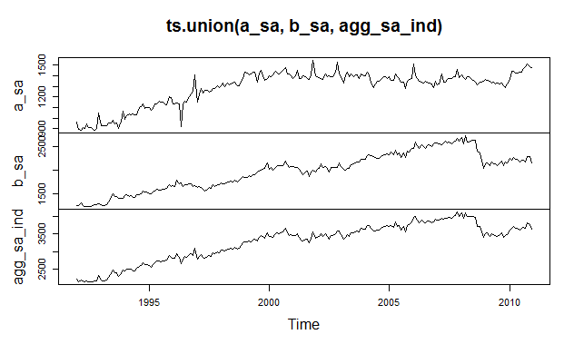

```r
agg_sa_ind<-a_sa+b_sa
plot(ts.union(a_sa, b_sa, agg_sa_ind))
```

We built the seasonally adjusted aggreagate. In the seasonal adjusted figure we can clearly see the outlier in December 1996. In the aggregate it is not noticeable in the same extent.

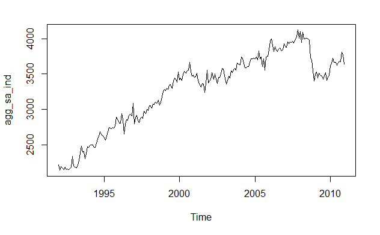

```r
plot(agg_sa_ind)
```

We want to test for seasonality. We see that the series neither displays seasonality for the QS Method nor the Friedman method.

```r
jd_seasonality(agg_sa_ind, test="QS")
```

```
[1] 0 1
attr(,"description")
[1] "Chi2(2)"
```

```r
jd_seasonality(agg_sa_ind, test="FRIEDMAN")
```

```
[1] 5.3846154 0.9111198
attr(,"description")
[1] "Chi2(11)"
```

# Direct Seasonal Adjustment

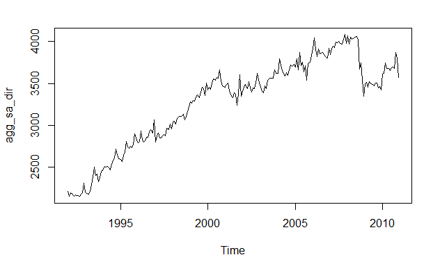

```r
agg_sa_dir_x13<-x13_def(agg,"RSA5")
agg_sa_dir<-agg_sa_dir_x13$final$series[,"sa"]
ts.plot( agg_sa_dir)
```

Again we check whether seasonaltiy remains in the seasonal adjusted series. We see there is no seasonality left.

```r
jd_seasonality(agg_sa_dir, test="QS")
```

```
[1] 0 1
attr(,"description")
[1] "Chi2(2)"
```

```r
jd_seasonality(agg_sa_dir, test="FRIEDMAN")
```

```
[1] 7.1111111 0.7900154
attr(,"description")
[1] "Chi2(11)"
```

# Comparing the results of the two methods

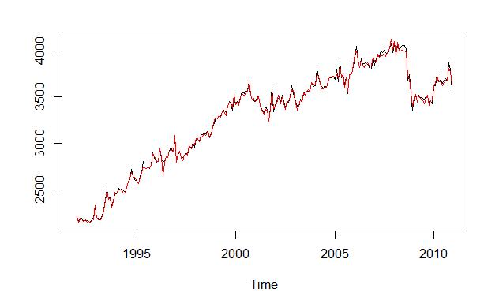

```r
ts.plot(ts.union(agg_sa_dir, agg_sa_ind), col=c("black", "red"))
```

The indirect method captures the downhill peak while the direct method eliminated it. We assume this is due to the outlier detection.

#### Outliers of series a

```r
a_x13$regarima$regression.coefficients
```

```
                 Estimate  Std. Error    T-stat
Monday       -0.008764791 0.003934539 -2.227654
Tuesday       0.013159964 0.003878265  3.393261
Wednesday    -0.009895807 0.003865620 -2.559953
Thursday     -0.004017940 0.003870716 -1.038035
Friday        0.014682504 0.004012317  3.659358
Saturday      0.011222854 0.003893308  2.882602
Easter [8]    0.067279471 0.007634677  8.812354
AO (5-1996)  -0.214292340 0.026854183 -7.979849
AO (12-1996)  0.152215672 0.026908581  5.656771
```

#### Outliers of series b

```r
b_x13$regarima$regression.coefficients
```

```
              Estimate  Std. Error     T-stat
Monday    -0.003032827 0.004119306 -0.7362471
Tuesday    0.006165951 0.004038651  1.5267352
Wednesday  0.001229607 0.004015651  0.3062037
Thursday  -0.001352646 0.004037175 -0.3350478
Friday     0.013886103 0.004024444  3.4504398
Saturday   0.007972993 0.004105509  1.9420228
```

#### Outliers of the aggregated series

```r
agg_sa_dir_x13$regarima$regression.coefficients
```

```
                Estimate  Std. Error     T-stat
Mean         0.036621506 0.008600201  4.2582153
Monday      -0.004004360 0.003506489 -1.1419854
Tuesday      0.011381478 0.003431020  3.3172285
Wednesday   -0.006220029 0.003411225 -1.8234004
Thursday    -0.002426206 0.003477147 -0.6977577
Friday       0.014203099 0.003512440  4.0436560
Saturday     0.009336833 0.003473300  2.6881736
Easter [8]   0.033092579 0.007074256  4.6778879
LS (9-2008) -0.113303810 0.023590716 -4.8028984
```

We notice that the two outliers May and December 1996 are found in series a but not in the aggregate of series a and b. However we find a new outlier in September 2008.

We can conclude that in this particular case direct seasonal adjustment make the outlier in May 1996 disappear.

```r
data.frame(month=1:12,
           direct=window(agg_sa_dir, c(1996,1), c(1996,12)),
           indirect=window(agg_sa_ind, c(1996,1), c(1996,12)))
```

| month | direct | indirect |
| --- | --- | --- |
| 1 | 2795.598 | 2802.508 |
| 2 | 2812.684 | 2803.287 |
| 3 | 2934.349 | 2937.950 |
| 4 | 2838.249 | 2852.878 |
| 5 | 2798.379 | 2654.990 |
| 6 | 2816.680 | 2800.098 |
| 7 | 2856.467 | 2859.426 |
| 8 | 2856.206 | 2850.804 |
| 9 | 2914.766 | 2913.877 |
| 10 | 2947.305 | 2936.227 |

[output cut: 2 more lines]

## Anaylsis of the differences

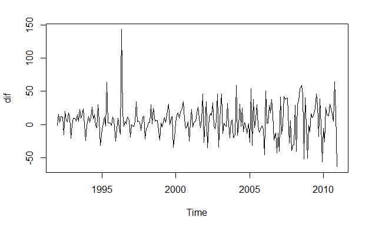

```r
dif<-agg_sa_dir-agg_sa_ind
plot(dif)
```

We can see seasonality in the difference of the two different seasonal adjusted aggregates.

```r
jd_seasonality(dif)
```

```
[1] 140.8304   0.0000
attr(,"description")
[1] "Chi2(2)"
```

This is confirmed by the test. So, why is that? What do you think?